# Term 1 & 2 EDA_Car Sales Data_Satyam_Gupta (2)

[figure not shown]

1. Problem Statement
2. Data Loading and Description
3. Pandas Profiling
4. Exploratory Data Analysis on various components & problem statement
5. Conclusion
6. Actionable Insights

## 1. Problem Statement

Data used in this analysis is taken from [link](https://raw.githubusercontent.com/insaid2018/Term-1/master/Data/Projects/car_sales.csv), there are various brands,type,etc of cars included in the dataset which is explored in this case study.

Our main objective for data analysis is to get the solution for below mentioned Business question:

1. Which brand of cars is most selling brand depending on user profiles?
2. which type of cars are more selling?
3. What are the factors affecting the price of cars?

## 2. Data Loading and Description

The dataset consists information collected from car sale advertisements for study/practice purpose where most of them're used cars. The dataset comprises of 9576 observations of 10 columns. Below is a table showing names of all the columns and their description. ColumnName | Description car | Manufacturer brand price | Seller’s price in advertisement (in USD) body | Car body type mileage | as mentioned in advertisement (‘000 Km) engV | rounded engine volume (‘000 cubic cm) engType | type of fuel (“Other” in this case should be treated as NA) registration | whether car registered in Ukraine or not year | year of production model | specific model name drive | drive type

```python
import numpy as np                                                 # Implemennts milti-dimensional array and matrices
import pandas as pd                                                # For data manipulation and analysis
import pandas_profiling
import matplotlib.pyplot as plt                                    # Plotting library for Python programming language and it's numerical mathematics extension NumPy
import seaborn as sns                                              # Provides a high level interface for drawing attractive and informative statistical graphics
%matplotlib inline
sns.set()

from subprocess import check_output
```

```python
carsale = pd.read_csv("https://raw.githubusercontent.com/insaid2018/Term-1/master/Data/Projects/car_sales.csv", engine='python', encoding='latin-1')     # Importing car_sale dataset using pd.read_csv
carsale.head(10)
```

|  | car | price | body | mileage | engV | engType | registration | year | model | drive |
| --- | --- | --- | --- | --- | --- | --- | --- | --- | --- | --- |
| 0 | Ford | 15500.0 | crossover | 68 | 2.5 | Gas | yes | 2010 | Kuga | full |
| 1 | Mercedes-Benz | 20500.0 | sedan | 173 | 1.8 | Gas | yes | 2011 | E-Class | rear |
| 2 | Mercedes-Benz | 35000.0 | other | 135 | 5.5 | Petrol | yes | 2008 | CL 550 | rear |
| 3 | Mercedes-Benz | 17800.0 | van | 162 | 1.8 | Diesel | yes | 2012 | B 180 | front |
| 4 | Mercedes-Benz | 33000.0 | vagon | 91 | NaN | Other | yes | 2013 | E-Class | NaN |
| 5 | Nissan | 16600.0 | crossover | 83 | 2.0 | Petrol | yes | 2013 | X-Trail | full |
| 6 | Honda | 6500.0 | sedan | 199 | 2.0 | Petrol | yes | 2003 | Accord | front |
| 7 | Renault | 10500.0 | vagon | 185 | 1.5 | Diesel | yes | 2011 | Megane | front |
| 8 | Mercedes-Benz | 21500.0 | sedan | 146 | 1.8 | Gas | yes | 2012 | E-Class | rear |
| 9 | Mercedes-Benz | 22700.0 | sedan | 125 | 2.2 | Diesel | yes | 2010 | E-Class | rear |

```python
carsale.shape    # This will print the number of rows and comlumns of the Data Frame
```

```
(9576, 10)
```

```python
carsale.columns  # This will print the names of all columns.
```

```
Index(['car', 'price', 'body', 'mileage', 'engV', 'engType', 'registration',
       'year', 'model', 'drive'],
      dtype='object')
```

```python
carsale.head()   # Will give you first 5 records
```

|  | car | price | body | mileage | engV | engType | registration | year | model | drive |
| --- | --- | --- | --- | --- | --- | --- | --- | --- | --- | --- |
| 0 | Ford | 15500.0 | crossover | 68 | 2.5 | Gas | yes | 2010 | Kuga | full |
| 1 | Mercedes-Benz | 20500.0 | sedan | 173 | 1.8 | Gas | yes | 2011 | E-Class | rear |
| 2 | Mercedes-Benz | 35000.0 | other | 135 | 5.5 | Petrol | yes | 2008 | CL 550 | rear |
| 3 | Mercedes-Benz | 17800.0 | van | 162 | 1.8 | Diesel | yes | 2012 | B 180 | front |
| 4 | Mercedes-Benz | 33000.0 | vagon | 91 | NaN | Other | yes | 2013 | E-Class | NaN |

```python
carsale.info() # This will give Index, Datatype and Memory information
```

```
<class 'pandas.core.frame.DataFrame'>
RangeIndex: 9576 entries, 0 to 9575
Data columns (total 10 columns):
car             9576 non-null object
price           9576 non-null float64
body            9576 non-null object
mileage         9576 non-null int64
engV            9142 non-null float64
engType         9576 non-null object
registration    9576 non-null object
year            9576 non-null int64
model           9576 non-null object
drive           9065 non-null object
dtypes: float64(2), int64(2), object(6)
memory usage: 748.2+ KB
```

```python
carsale.describe()
```

|  | price | mileage | engV | year |
| --- | --- | --- | --- | --- |
| count | 9576.000000 | 9576.000000 | 9142.000000 | 9576.000000 |
| mean | 15633.317316 | 138.862364 | 2.646344 | 2006.605994 |
| std | 24106.523436 | 98.629754 | 5.927699 | 7.067924 |
| min | 0.000000 | 0.000000 | 0.100000 | 1953.000000 |
| 25% | 4999.000000 | 70.000000 | 1.600000 | 2004.000000 |
| 50% | 9200.000000 | 128.000000 | 2.000000 | 2008.000000 |
| 75% | 16700.000000 | 194.000000 | 2.500000 | 2012.000000 |
| max | 547800.000000 | 999.000000 | 99.990000 | 2016.000000 |

**Observations:** We can see all numeric columns having count 9576 except engV. Looks like this column has some missing values price and mileage has min value as Zero which is not possible. We need to look into to replace them as NaN to make them null values

```python
carsale.isnull().sum() # Will show you null count for each column, but will not count Zeros(0) as null
```

```
car               0
price             0
body              0
mileage           0
engV            434
engType           0
registration      0
year              0
model             0
drive           511
dtype: int64
```

**Observations:** We can see that engV and drive columns contains maximum null values. But it didn't consider 0 as missing value, so we have to figure out how to deal with this as mentioned above too

## 3. Pandas Profiling

```python
profile = pandas_profiling.ProfileReport(carsale)
profile.to_file(output_file="carsale_pre_profiling_1.html")
```

**Observations:**

- Preprofiling_1

engType column has "Other" values as well, So as mentioned above in data description, we should treat them as NA. So we'll be replacing those to NaN price has 267 zeros which should be treated as missing values. So we'll be replacing those to NaN mileage has 348 zeros which should be treated as missing values. So we'll be replacing those to NaN

```python
carsale.replace({'engType': 'Other', 'price': 0, 'mileage': 0}, np.nan, inplace=True)
```

```python
profile = pandas_profiling.ProfileReport(carsale)
profile.to_file(output_file="carsale_pre_profiling_2.html")
```

- Preprofiling_2

Now we will deal with handling duplicates and missing values

duplicates: As there are 113 duplicate rows in dataset, we have to remove those first

```python
carsale.drop_duplicates(inplace=True) #inplace used to modify the dataset with applied command
carsale.shape
```

```
(9463, 10)
```

Handling numerical data price: Replacing missing values now for price column based on [car,model] group product and median value of price based on this group.

```python
def get_median_price(x):
    brand = x.name[0]
    if x.count() > 0:
        return x.median() # Return median for a brand/model if the median exists.
    elif carsale.groupby(['car'])['price'].count()[brand] > 0:
        brand_median = carsale.groupby(['car'])['price'].apply(lambda x: x.median())[brand]
        return brand_median # Return median of brand if particular brand/model combo has no median,
    else:                 # but brand itself has a median for the 'price' feature.
        return carsale['price'].median() # Otherwise return dataset's median for the 'price' feature.

price_median = carsale.groupby(['car','model'])['price'].apply(get_median_price).reset_index()
price_median.rename(columns={'price': 'price_med'}, inplace=True)
price_median.head()
```

|  | car | model | price_med |
| --- | --- | --- | --- |
| 0 | Acura | MDX | 17200.0 |
| 1 | Acura | RL | 13950.0 |
| 2 | Acura | TL | 8699.0 |
| 3 | Acura | TLX | 38200.0 |
| 4 | Acura | ZDX | 30999.0 |

```python
def fill_with_median(x):
    if pd.isnull(x['price']):
        return price_median[(price_median['car'] == x['car']) & (price_median['model'] == x['model'])]['price_med'].values[0]
    else:
        return x['price']

carsale['price'] = carsale.apply(fill_with_median, axis=1)
carsale.head()
```

|  | car | price | body | mileage | engV | engType | registration | year | model | drive |
| --- | --- | --- | --- | --- | --- | --- | --- | --- | --- | --- |
| 0 | Ford | 15500.0 | crossover | 68.0 | 2.5 | Gas | yes | 2010 | Kuga | full |
| 1 | Mercedes-Benz | 20500.0 | sedan | 173.0 | 1.8 | Gas | yes | 2011 | E-Class | rear |
| 2 | Mercedes-Benz | 35000.0 | other | 135.0 | 5.5 | Petrol | yes | 2008 | CL 550 | rear |
| 3 | Mercedes-Benz | 17800.0 | van | 162.0 | 1.8 | Diesel | yes | 2012 | B 180 | front |
| 4 | Mercedes-Benz | 33000.0 | vagon | 91.0 | NaN | NaN | yes | 2013 | E-Class | NaN |

engV: Replacing missing values now for engV column based on [car,model] group product and median value of engV based on this group.

```python
def get_median_engV(x):
    brand = x.name[0]
    if x.count() > 0:
        return x.median() # Return median for a brand/model if the median exists.
    elif carsale.groupby(['car'])['engV'].count()[brand] > 0:
        brand_median = carsale.groupby(['car'])['engV'].apply(lambda x: x.median())[brand]
        return brand_median # Return median of brand if particular brand/model combo has no median,
    else:                 # but brand itself has a median for the 'engV' feature.
        return carsale['engV'].median() # Otherwise return dataset's median for the 'engV' feature.

engV_median = carsale.groupby(['car','model'])['engV'].apply(get_median_engV).reset_index()
engV_median.rename(columns={'engV': 'engV_med'}, inplace=True)
engV_median.head()
```

|  | car | model | engV_med |
| --- | --- | --- | --- |
| 0 | Acura | MDX | 3.7 |
| 1 | Acura | RL | 3.5 |
| 2 | Acura | TL | 3.2 |
| 3 | Acura | TLX | 2.4 |
| 4 | Acura | ZDX | 3.7 |

```python
def fill_with_median(x):
    if pd.isnull(x['engV']):
        return engV_median[(engV_median['car'] == x['car']) & (engV_median['model'] == x['model'])]['engV_med'].values[0]
    else:
        return x['engV']

carsale['engV'] = carsale.apply(fill_with_median, axis=1)
carsale.head()
```

|  | car | price | body | mileage | engV | engType | registration | year | model | drive |
| --- | --- | --- | --- | --- | --- | --- | --- | --- | --- | --- |
| 0 | Ford | 15500.0 | crossover | 68.0 | 2.5 | Gas | yes | 2010 | Kuga | full |
| 1 | Mercedes-Benz | 20500.0 | sedan | 173.0 | 1.8 | Gas | yes | 2011 | E-Class | rear |
| 2 | Mercedes-Benz | 35000.0 | other | 135.0 | 5.5 | Petrol | yes | 2008 | CL 550 | rear |
| 3 | Mercedes-Benz | 17800.0 | van | 162.0 | 1.8 | Diesel | yes | 2012 | B 180 | front |
| 4 | Mercedes-Benz | 33000.0 | vagon | 91.0 | 2.6 | NaN | yes | 2013 | E-Class | NaN |

```python
def get_median_mileage(x):
    brand = x.name[0]
    if x.count() > 0:
        return x.median() # Return median for a brand/model if the median exists.
    elif carsale.groupby(['car'])['mileage'].count()[brand] > 0:
        brand_median = carsale.groupby(['car'])['mileage'].apply(lambda x: x.median())[brand]
        return brand_median # Return median of brand if particular brand/model combo has no median,
    else:                 # but brand itself has a median for the 'mileage' feature.
        return carsale['mileage'].median() # Otherwise return dataset's median for the 'mileage' feature.

mileage_median = carsale.groupby(['car','model'])['mileage'].apply(get_median_mileage).reset_index()
mileage_median.rename(columns={'mileage': 'mileage_med'}, inplace=True)
mileage_median.head()
```

|  | car | model | mileage_med |
| --- | --- | --- | --- |
| 0 | Acura | MDX | 85.0 |
| 1 | Acura | RL | 138.0 |
| 2 | Acura | TL | 145.0 |
| 3 | Acura | TLX | 4.0 |
| 4 | Acura | ZDX | 32.0 |

```python
def fill_with_median(x):
    if pd.isnull(x['mileage']):
        return mileage_median[(mileage_median['car'] == x['car']) & (mileage_median['model'] == x['model'])]['mileage_med'].values[0]
    else:
        return x['mileage']

carsale['mileage'] = carsale.apply(fill_with_median, axis=1)
carsale.head()
```

|  | car | price | body | mileage | engV | engType | registration | year | model | drive |
| --- | --- | --- | --- | --- | --- | --- | --- | --- | --- | --- |
| 0 | Ford | 15500.0 | crossover | 68.0 | 2.5 | Gas | yes | 2010 | Kuga | full |
| 1 | Mercedes-Benz | 20500.0 | sedan | 173.0 | 1.8 | Gas | yes | 2011 | E-Class | rear |
| 2 | Mercedes-Benz | 35000.0 | other | 135.0 | 5.5 | Petrol | yes | 2008 | CL 550 | rear |
| 3 | Mercedes-Benz | 17800.0 | van | 162.0 | 1.8 | Diesel | yes | 2012 | B 180 | front |
| 4 | Mercedes-Benz | 33000.0 | vagon | 91.0 | 2.6 | NaN | yes | 2013 | E-Class | NaN |

- Handling categorical data drive: Replacing missing values now for drive column based on [car,model] group product and mode value of drive based on this group

```python
def get_drive_mode(x):
    brand = x.name[0]
    if x.count() > 0:
        return x.mode() # Return mode for a brand/model if the mode exists.
    elif carsale.groupby(['car'])['drive'].count()[brand] > 0:
        brand_mode = carsale.groupby(['car'])['drive'].apply(lambda x: x.mode())[brand]
        return brand_mode # Return mode of brand if particular brand/model combo has no mode,
    else:                 # but brand itself has a mode for the 'drive' feature.
        return carsale['drive'].mode() # Otherwise return dataset's mode for the 'drive' feature.

drive_modes = carsale.groupby(['car','model'])['drive'].apply(get_drive_mode).reset_index().drop('level_2', axis=1)
drive_modes.rename(columns={'drive': 'drive_mode'}, inplace=True)
drive_modes.head()
```

|  | car | model | drive_mode |
| --- | --- | --- | --- |
| 0 | Acura | MDX | full |
| 1 | Acura | RL | full |
| 2 | Acura | TL | front |
| 3 | Acura | TLX | front |
| 4 | Acura | ZDX | full |

```python
def fill_with_mode(x):
    if pd.isnull(x['drive']):
        return drive_modes[(drive_modes['car'] == x['car']) & (drive_modes['model'] == x['model'])]['drive_mode'].values[0]
    else:
        return x['drive']

carsale['drive'] = carsale.apply(fill_with_mode, axis=1)
carsale.head()
```

|  | car | price | body | mileage | engV | engType | registration | year | model | drive |
| --- | --- | --- | --- | --- | --- | --- | --- | --- | --- | --- |
| 0 | Ford | 15500.0 | crossover | 68.0 | 2.5 | Gas | yes | 2010 | Kuga | full |
| 1 | Mercedes-Benz | 20500.0 | sedan | 173.0 | 1.8 | Gas | yes | 2011 | E-Class | rear |
| 2 | Mercedes-Benz | 35000.0 | other | 135.0 | 5.5 | Petrol | yes | 2008 | CL 550 | rear |
| 3 | Mercedes-Benz | 17800.0 | van | 162.0 | 1.8 | Diesel | yes | 2012 | B 180 | front |
| 4 | Mercedes-Benz | 33000.0 | vagon | 91.0 | 2.6 | NaN | yes | 2013 | E-Class | rear |

```python
def get_engType_mode(x):
    brand = x.name[0]
    if x.count() > 0:
        return x.mode() # Return mode for a brand/model if the mode exists.
    elif carsale.groupby(['car'])['engType'].count()[brand] > 0:
        brand_mode = carsale.groupby(['car'])['engType'].apply(lambda x: x.mode())[brand]
        return brand_mode # Return mode of brand if particular brand/model combo has no mode,
    else:                 # but brand itself has a mode for the 'engType' feature.
        return carsale['engType'].mode() # Otherwise return dataset's mode for the 'engType' feature.

engType_modes = carsale.groupby(['car','model'])['engType'].apply(get_engType_mode).reset_index().drop('level_2', axis=1)
engType_modes.rename(columns={'engType': 'engType_mode'}, inplace=True)
engType_modes.head()
```

|  | car | model | engType_mode |
| --- | --- | --- | --- |
| 0 | Acura | MDX | Petrol |
| 1 | Acura | RL | Gas |
| 2 | Acura | TL | Gas |
| 3 | Acura | TLX | Petrol |
| 4 | Acura | ZDX | Petrol |

```python
def fill_with_mode(x):
    if pd.isnull(x['engType']):
        return engType_modes[(engType_modes['car'] == x['car']) & (engType_modes['model'] == x['model'])]['engType_mode'].values[0]
    else:
        return x['engType']

carsale['engType'] = carsale.apply(fill_with_mode, axis=1)
carsale.head()
```

|  | car | price | body | mileage | engV | engType | registration | year | model | drive |
| --- | --- | --- | --- | --- | --- | --- | --- | --- | --- | --- |
| 0 | Ford | 15500.0 | crossover | 68.0 | 2.5 | Gas | yes | 2010 | Kuga | full |
| 1 | Mercedes-Benz | 20500.0 | sedan | 173.0 | 1.8 | Gas | yes | 2011 | E-Class | rear |
| 2 | Mercedes-Benz | 35000.0 | other | 135.0 | 5.5 | Petrol | yes | 2008 | CL 550 | rear |
| 3 | Mercedes-Benz | 17800.0 | van | 162.0 | 1.8 | Diesel | yes | 2012 | B 180 | front |
| 4 | Mercedes-Benz | 33000.0 | vagon | 91.0 | 2.6 | Diesel | yes | 2013 | E-Class | rear |

```python
carsale.isnull().sum()
```

```
car             0
price           0
body            0
mileage         0
engV            0
engType         0
registration    0
year            0
model           0
drive           0
dtype: int64
```

```python
import pandas_profiling
profile = pandas_profiling.ProfileReport(carsale)
profile.to_file(output_file="carsale_post-profiling.html")
```

## 4. Exploratory Data Analysis on various components & problem statement

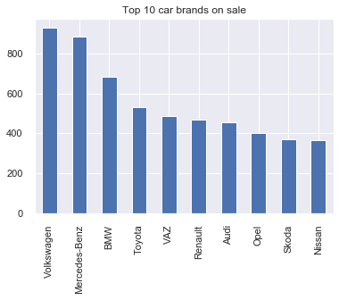

```python
carsale.car.value_counts().head(10).plot.bar()
plt.title("Top 10 car brands on sale")
```

This shows Volkswagen and Mercedes-Benz are top most brands on sale and hence these would be preferred choices for high profile people

```python
carsale[carsale.price.isin(carsale.price.nlargest())].sort_values(['car','model','body','mileage','price'])
```

|  | car | price | body | mileage | engV | engType | registration | year | model | drive |
| --- | --- | --- | --- | --- | --- | --- | --- | --- | --- | --- |
| 4134 | Bentley | 449999.0 | crossover | 1.0 | 6.00 | Petrol | yes | 2016 | Bentayga | full |
| 2637 | Bentley | 474999.0 | crossover | 1.0 | 6.00 | Petrol | yes | 2016 | Bentayga | full |
| 1611 | Bentley | 499999.0 | crossover | 1.0 | 6.00 | Petrol | yes | 2016 | Bentayga | full |
| 7621 | Bentley | 547800.0 | sedan | 49.5 | 6.75 | Petrol | yes | 2016 | Mulsanne | rear |
| 5849 | Mercedes-Benz | 300000.0 | other | 37.0 | 5.00 | Petrol | yes | 2012 | G 500 | full |
| 4325 | Mercedes-Benz | 300000.0 | sedan | 68.0 | 6.00 | Petrol | yes | 2011 | S 600 | rear |

This shows top 5 highest price selling car and their models details and hence can be used for email marketing for high profile income group peoples to achieve sales goals

```python
carsale[carsale.price.isin(carsale.price.nsmallest())].sort_values(['car','model','body','mileage','price'])
```

|  | car | price | body | mileage | engV | engType | registration | year | model | drive |
| --- | --- | --- | --- | --- | --- | --- | --- | --- | --- | --- |
| 5010 | GAZ | 259.350 | sedan | 1.0 | 2.4 | Petrol | yes | 1959 | 21 | rear |
| 6457 | Moskvich-AZLK | 280.000 | sedan | 99.0 | 1.5 | Petrol | yes | 1976 | 2140 | rear |
| 7566 | Moskvich-AZLK | 350.000 | sedan | 100.0 | 1.5 | Petrol | yes | 1985 | 2140 | rear |
| 4905 | VAZ | 389.025 | vagon | 1.0 | 1.3 | Petrol | yes | 1983 | 2102 | rear |
| 8252 | ZAZ | 370.500 | sedan | 3.0 | 1.1 | Petrol | yes | 1989 | 968 | rear |

This shows top 5 lowest price selling car and their models details and hence can be used for email marketing for low to middle profile income group peoples to achieve sales goals

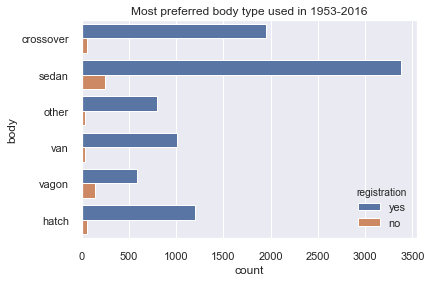

```python
sns.countplot(y='body', data=carsale, orient='h', hue='registration')
plt.title("Most preferred body type used in 1953-2016")
```

This shows the car brands having "sedan" type of body having maximum registration/sale over the years. This shows People prefers sedan type of body mostly and hence this information can be use for achieving max sale and to figure out production of units.

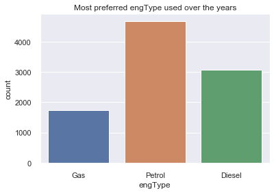

```python
sns.countplot(x='engType', data=carsale, orient='h')
plt.title("Most preferred engType used over the years")
```

|  | year | registration | RegCounts |
| --- | --- | --- | --- |
| 0 | 2008 | yes | 1142 |
| 1 | 2007 | yes | 914 |
| 2 | 2012 | yes | 749 |
| 3 | 2011 | yes | 681 |
| 4 | 2013 | yes | 632 |

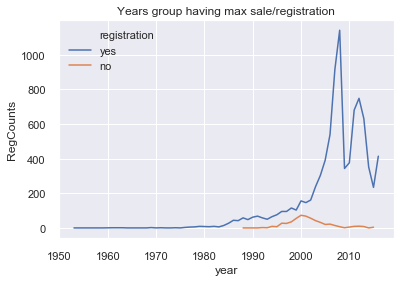

```python
carsale.sort_values(['car','model','body','mileage','year'])

df = carsale.groupby('year')['registration'].value_counts().sort_values(ascending=False)
df = pd.DataFrame(df)
df.rename(columns={'registration': 'RegCounts'}, inplace=True)
df.reset_index(inplace=True)
display(df.head())
sns.lineplot(data=df, x='year', y='RegCounts', hue='registration')
#sns.scatterplot(data=df, x='year', y='RegCounts', hue='registration')
plt.title("Years group having max sale/registration")
```

This graph shows in which Year was the highest registrations, and hence shows max sale was done in the Year 2008. This info can be use to start working/research why sale was max in this year. What was the factors affected this sale/registrations

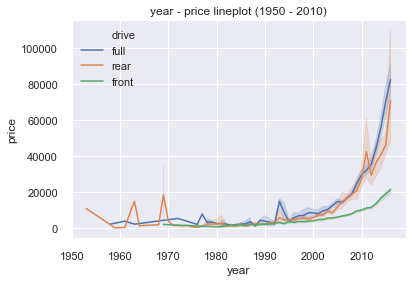

```python
sns.lineplot(data=carsale, y='price', x='year', hue='drive')
plt.title("year - price lineplot (1950 - 2010)")
```

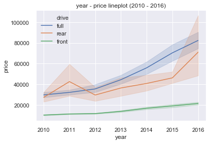

```python
sns.lineplot(data=carsale[carsale.year >= 2010], y='price', x='year', hue='drive')
plt.title("year - price lineplot (2010 - 2016)")
```

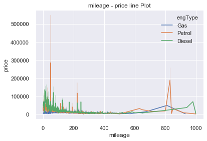

```python
sns.lineplot(x='mileage',y='price',data=carsale, hue='engType')
plt.title("mileage - price line Plot")
```

The above graph shows line plot/relation between mileage and price. We can't comment on the price increase/decrease over the mileage but this shows, price changing accordingly based on mileage value. So price is varying based on mileage too and this should be consider as a factor for the calculation.

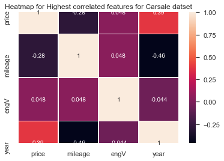

```python
sns.heatmap(carsale.corr(),annot=True, linewidths=.5)
plt.title("Heatmap for Highest correlated features for Carsale datset")
```

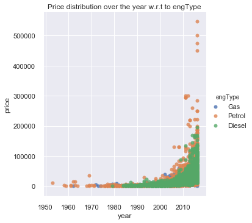

```python
sns.lmplot('year','price', carsale, fit_reg=False, hue='engType')
plt.title("Price distribution over the year w.r.t to engType")
```

The above multivariate graphs shows the Price distribution over the years w.r.t engType. As the years increase, this shows there is significant increase in prices of cars models having engine tyep = "Petrol" as compared to "Gas" and "Diesel".

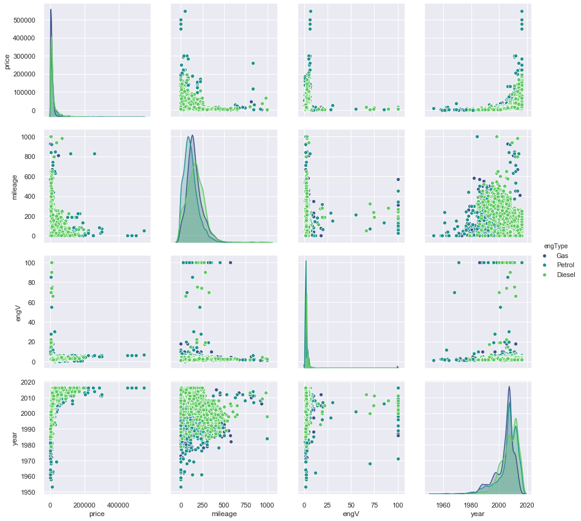

```python
sns.pairplot(carsale, hue='engType', palette="viridis", height=3)
```

This pairplot gives the observations which already have been referred from other graphs above : those are Price varying based on Year and Mileage As Year increases there is increase in Petrol engine type vehicles's prices which also depending on mileage too

## 5. Conclusion:

**1. Which brand of cars is most selling brand ?**

- From above analysis we can conclude that ,Volkswagen and Mercedes-Benz are top most brands on sale and hence these would be preferred choices for high profile people.

**2. which type of cars are more selling?**

- "sedan" type of body having maximum registration/sale over the years. This shows People prefers sedan type of body mostly and hence this information can be use for achieving max sale and to figure out production of units.

**3. What are the factors affecting the price of cars?**

- Price changing accordingly based on mileage value, So price is varying based on mileage too and this should be consider as a factor for the calculation
- Petrol engine type is preferred over diesel & gas.